# Strain and Breakdown

# Where does collective action come from?

## Assessing theories

- Social science has few “laws” or even consistent rules. All social science theories are false to some extent.
- Some useful ways to assess theories are:
  - **Predictive/Explanatory power**: does the theory explain things? Does it allow us to make sound predictions?
  - **Parsimony**: does the theory avoid needless complexity?
  - **Productivity**: does the theory generate useful research questions? Do unexpected findings allow us to make progressive refinements to the core assumptions?

## Early theories of collective action: Gustav LeBon

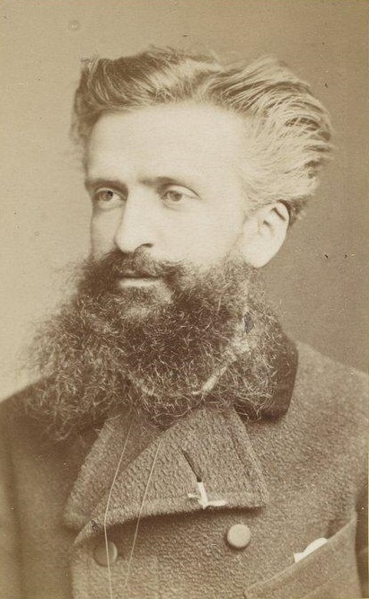

Gustav LeBon. By Jean-Nicolas Truchelut - This file comes from Gallica Digital Library and is available under the digital ID btv1b84506208, Public Domain

## Context for LeBon

[figure not shown]

## The Franco Prussian War: July 1870 - May 1871

- France starts a war with Prussia, this goes poorly…
- Napoleon III captured, and Paris is besieged by Prussian forces for 4 months

[figure not shown]

## The Third Republic (September 1870 until 1940)

- France forms a new government following Napoleon’s capture, but (comparatively radical) Paris doesn’t get much say in the process.
- The new legislative assembly is dominated by conservatives. The capital is relocated to Versailles and France signs an armistice with Prussia.
- Parisians refuse to disarm, and declare a parallel government in March 1871.

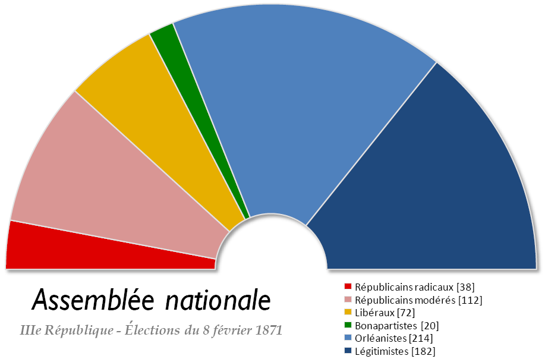

French legislative assembly in 1871

## The Paris Commune (March 1871 - May 1871)

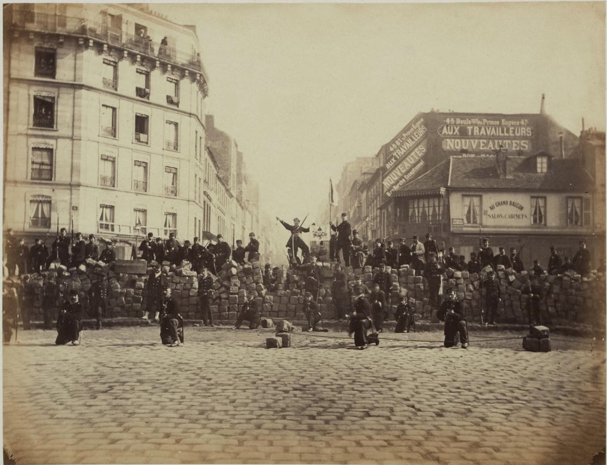

A barricade in the Paris Commune, March 18, 1871.

## Resolution

- By May 1871, the national gov. suppresses the rebellion
- The entire commune lasts 2 months.
- 10,000 - 20,000 dead, nearly 50,000 arrested.

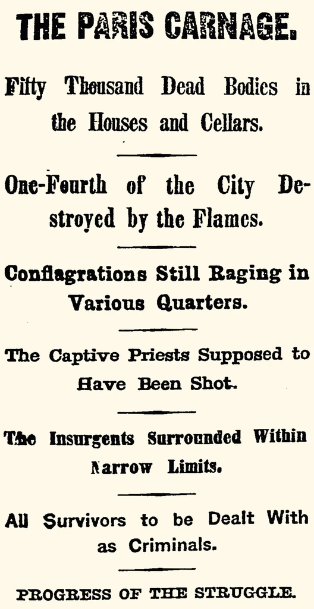

New York Times: Front-page news, May 28, 1871

## LeBon’s take

*The howling, swarming, ragged crowd which invaded the Tuileries during the revolution of 1848 did not lay hands on any of the objects that excited its astonishment, and one of which would have meant bread for many days.* - Gustav LeBon

[figure not shown]

Lithographie de Léon Sabatier et Albert Adam pour l’ouvrage de Victor Fournel, Paris et ses ruines publié en 1873.

## Gustav LeBon: The Crowd

For LeBon: **crowd psychology is not like individual psychology**

- Crowds allow anonymity, which makes people feel less restrained.
- Unconscious/instinctive drives take precedence over conscious ones (LeBon views race, in particular, as an important source of these drives)
- They become highly suggestible, akin to being hypnotized, and they’re prone to impulsiveness and irritability.
- As countries democratize, crowds become central to politics

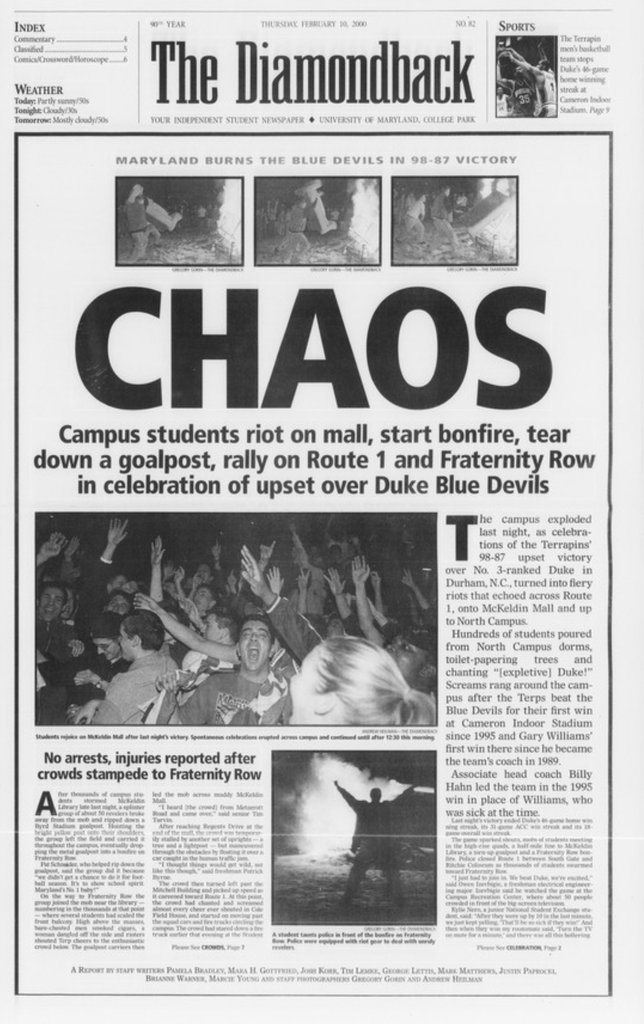

## Group Psychology and Collective Behavior

- The study of crowd psychology (particularly pathological and violent behaviors) is revived in the early/mid 20th century. (why?)
- These 20th century theories can be classed in two broad paradigms:
  - Transformation accounts
  - Social strain/predisposition accounts

## Transformation Accounts

Blumer’s “Elementary Collective Action”

1. Disruption of routine (disaster, celebration, societal breakdown etc)
2. Milling (people stand around and talk)
3. People focus on a shared object or concern
4. Common impulses emerge to take the place of normal routines
5. Collective behavior emerges

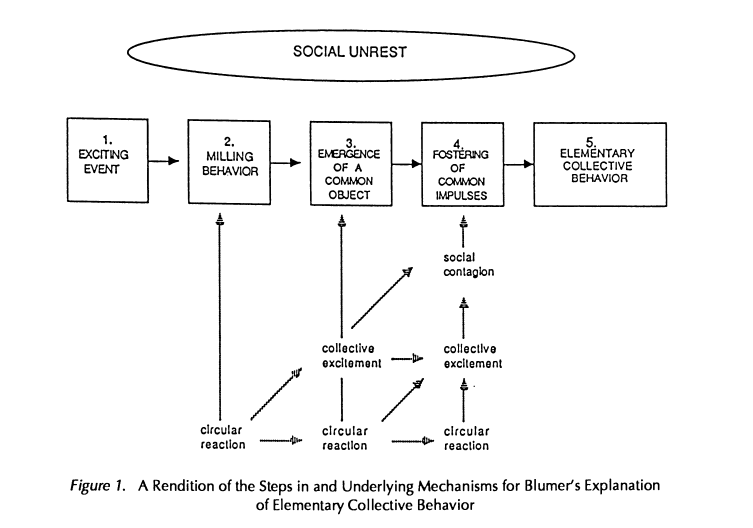

Illustration of Blumer’s model of collective behavior. From McPhail, Clark. The myth of the madding crowd. Routledge, 2017.

## Strain, breakdown and mass society

- Structural strain, societal breakdown, or “anomie” makes people want to deviate from norms
  - Causes of strain might be: urbanization, industrialization, economic crises etc.
- The relative safety/anonymity of the crowd makes people more willing to engage in norm-violating behaviors
- Crowds may not be “transformative”, but they give people license to act on their worst impulses.

**Example: Relative Deprivation**

*…relative deprivation, is the basic precondition for civil strife of any kind…the more widespread and intense deprivation is among members of a population, the greater is the magnitude of strife in one or another form*

— Gurr, T. (1968). A causal model of civil strife: a comparative analysis using new indices1. American political science review, 62(4), 1104-1124.

## Strain and transformation theories: some expectations

- Crowd psychology is distinct from individual psychology. Crowds are “transformative”
  - Primarily through mechanisms of anonymity and disruption of routines
- Crowds are more driven by emotion than reason, and are more spontaneous than deliberate, and more expressive than strategic, and they’re gullible and easily misled.
- Crowds are mobilized by social strain and societal breakdown, and participants are more likely to come from groups that are aggrieved, or less integrated into society.

## Issues

- Are there scenarios where this makes sense? Are there scenarios where it doesn’t?
- Why does this start to see sustained pushback in the later 60s and 70s?

## Are crowds anonymous and spontaneous?

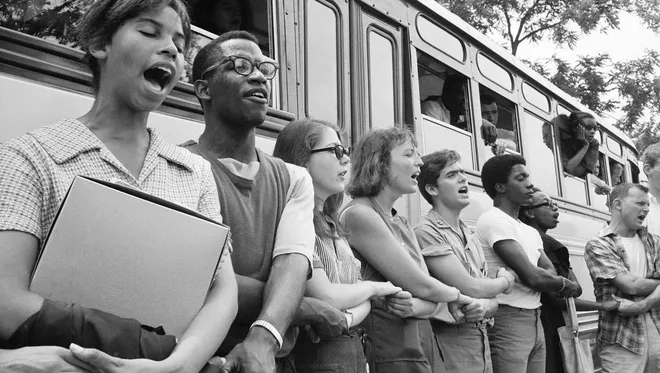

Student activists on their way to register voters in Mississippi in 1964.

## Are crowds anonymous and spontaneous?

Strain theories emphasize the role of disorder, “anomie” and societal breakdown, to explain contentious behavior, but:

- At least in some cases, being part of organizations and networks is a positive predictor of participating in contentious behavior.
- “Anti-social crowds” are an oxymoron. Sustained collective action requires people who can play nice with others.

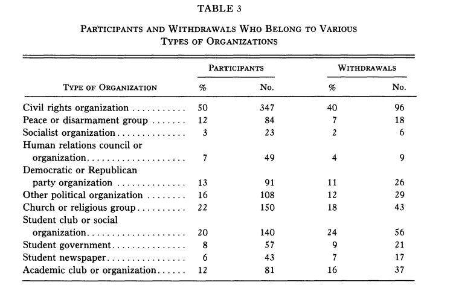

McAdam, Doug. “Recruitment to high-risk activism: The case of freedom summer.” American journal of sociology 92.1 (1986): 64-90.

## Are crowds unrestrained?

- The strain and transformation models both assume crowds will act on instinct, but empirical studies often contradict this assumption

## The Who concert disaster

[figure not shown]

## The Who concert disaster

Crowd characterized as reverting to “animal instincts”, but:

- “Stampede” was more accurately described as a progressive crowd collapse: people fell when a door collapsed, and then others fell on top of them.
- Most victims reported helping others, receiving help, or witnessing strangers helping someone else.
- Cultural norms (particularly gender norms) played a predictable role.

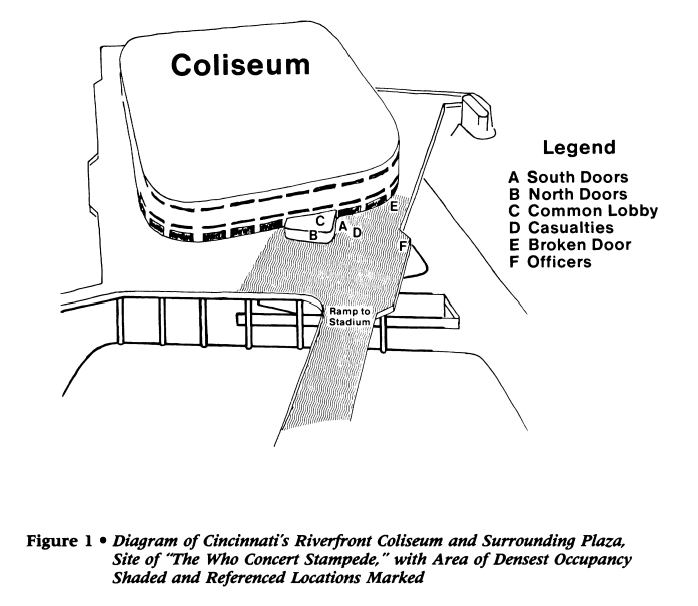

Johnson, Norris R. “Panic at ‘The Who Concert Stampede’: An Empirical Assessment.” Social Problems, vol. 34, no. 4, 1987, pp. 362–73. JSTOR, https://doi.org/10.2307/800813.

## Are crowds uniquely suggestible?

- People are suggestible in small AND large groups
- Conformity to norms can just as easily enable violence as work against it
  - Milgram’s study of obedience shows people willing to abdicate responsibility even in normal conditions with just one other person.

[figure not shown]

Illustration of Milgram’s 1963 Behavioral Study of Obedience

## Does deprivation or strain lead to violence?

Strain theories emphasize the role of social strain, grievance, and anomie, but:

- Patterns of unrest don’t neatly correlate with grievances
  - People are aggrieved all over the world, but violent rebellion is the exception rather than the norm!
  - Surveys show activists and even riot participants are often well-integrated into their communities.
- Experimental studies find weak support for the frustration-aggression relationship.

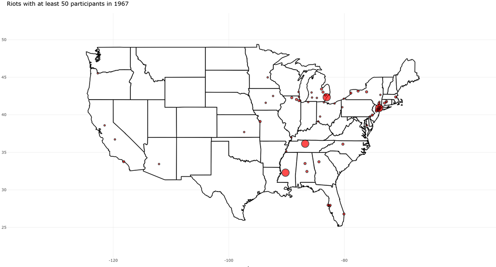

## Revisiting the Paris Commune

Does LeBon’s characterization ring true?

- The Communards are organized and embedded in local networks and institutions. The rebellion is a product of organization, not chaos.
- Their actions deliberately draw on culturally relevant symbols and behaviors, not on “animal instinct”
  - Barricades
  - Committees
  - Declarations, occupations, revolutionary governments
- They’re violent and irrational… but so is everyone else.
  - Collective action is always difficult. Governments do it better than rebels because they have more resources.

## Critique

- Sustained collective resistance often highly organized and sophisticated, and people maintain some self control even in a riot.
- Forms of collective action are historically contingent and adapt to cultural norms, policing, government structure etc. They’re clearly not pure instinct.
- Far from being anonymous, participants often know each other! Being part of a social network makes you more likely to protest.
- Unrest and deprivation are not neatly correlated (at a minimum, “strain” alone can’t explain rebellion)

## Takeaways

- Collective behavior tradition remains influential, but see serious challenges in the 1960s.
- Contentious behavior is no less rational (in the narrow rational-choice sense) than individual behavior.

## Going forward

Contemporary theories of contentious behavior generally place more emphasis on:

- The role of organization, structure, and resources in explaining contentious behavior over the role of social strain or grievance
- The social and political context for collective action, over studying “crowds” on their own; continuity between conventional state-approved political behavior and non-conventional forms.
- The importance of rationality over pathologies (even for extreme behaviors like genocide or terrorism)

[figure not shown]